# Reproducible Research: Peer Assignment 1

Suhas P K

2023-05-04

## Introduction

- Large amount of data about personal movement can be collected from activity monitoring devices such as ‘Fitbits’, ‘Jawbone Up’ etc.
- A group of enthusiasts took measurements about themselves regularly to improve their health, to find patterns on their behaviour, or because they are tech geek.
- The obtained data activity monitor data is raw data, proper tools are required to clean the data in a more understandable format.

## About data:

- The data can be downloaded from here -> activity monitor data.
- The variables included in the data are:
- **steps**: Number of steps taking on a 5-minute interval (missing values are coded as NA)
- **date** : The date on which the measurement was taken in YYYY-MM-DD format.
- **interval** : Identifier for the 5-minute interval in which measurement was take.

### The code for this assignment is given with as minimal texts to answer and understand the code.

## Lets load the data

```r
activity <- read.csv("activity.csv")
head(activity)
```

```
##   steps       date interval
## 1    NA 2012-10-01        0
## 2    NA 2012-10-01        5
## 3    NA 2012-10-01       10
## 4    NA 2012-10-01       15
## 5    NA 2012-10-01       20
## 6    NA 2012-10-01       25
```

## What is mean total number of steps taken per day?

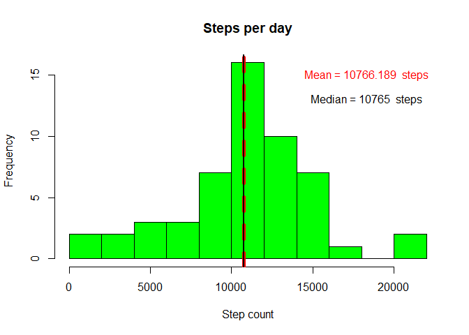

```r
# What is mean total mean number of steps taken per day?
stepsPerDay <- aggregate(steps ~ date, activity, sum)
# mean and median of step count per day.
mean_StepsPerDay <- round(mean(stepsPerDay$steps),digits = 3)
median_StepsPerDay <- round(median(stepsPerDay$steps), digits = 3)

# plotting
hist(stepsPerDay$steps, main = "Steps per day", xlab = "Step count", col = "green", breaks = 8)
abline(v = mean_StepsPerDay,col = "red", lty ="dashed" ,lwd = 5 )
text(x = mean_StepsPerDay*1.7, y = 15 ,
     paste("Mean =", mean_StepsPerDay," steps"), col ="red", cex = 1 )
abline(v=median_StepsPerDay, col="black",lwd=2)
text(x = median_StepsPerDay*1.7, y = 13,
     paste("Median =", median_StepsPerDay, " steps"), col = "black", cex=1)
```

## What is the average daily activity pattern?

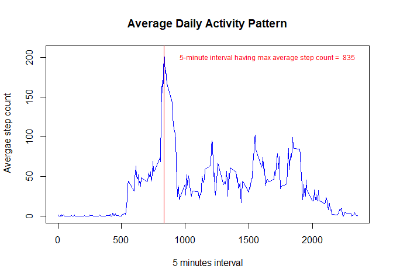

```r
# What is the average daily activity pattern?
average_interval <- aggregate(steps~interval, activity, mean, na.rm = TRUE)
# plotting
plot(x = average_interval$interval, y =average_interval$steps,
     type = "l", xlab = "5 minutes interval", ylab = " Avergae step count",
     main = "Average Daily Activity Pattern", col = "blue")
max_step_interval <- average_interval$interval[which.max(average_interval$steps)]
abline(v= max_step_interval, col = "red", lwd = 1.5)
text(x = 1650, y =200,
     paste("5-minute interval having max average step count = ",max_step_interval),col="red",cex=0.75)
```

## Imputing missing value

- Note that there are a number of days/intervals where there are missing value (coded as NA). The presence of missing days may introduce bias into some caluculations or summaries of the data.

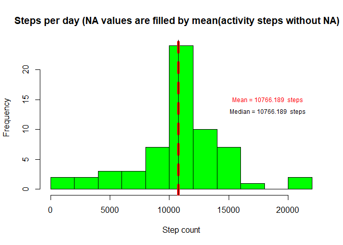

```r
# Imputing the missing values
# Calculate and report the total number of missing values in the dataset.
missing_values <- sum(!complete.cases(activity)==TRUE)

# Replace NA values by 0 for the 5min interval.
activity[is.na(activity$steps),"steps"] <- mean(activity$steps,na.rm = TRUE)

stepsPerDay_noNA <- aggregate(steps ~ date, activity, sum)
# mean and median of step count per day.
mean_StepsPerDay_noNA <- round(mean(stepsPerDay_noNA$steps),digits = 3)
median_StepsPerDay_noNA <- round(median(stepsPerDay_noNA$steps), digits = 3)

# plotting

hist(stepsPerDay_noNA$steps, main = "Steps per day (NA values are filled by mean(activity steps without NA)  )", xlab = "Step count", col = "green", breaks = 8)
abline(v = mean_StepsPerDay_noNA,col = "red", lty ="dashed" ,lwd = 5 )
text(x = mean_StepsPerDay_noNA*1.7, y = 15 ,
     paste("Mean =", mean_StepsPerDay_noNA," steps"), col ="red", cex = 0.75 )
abline(v=median_StepsPerDay_noNA, col="black",lwd=0.85)
text(x = median_StepsPerDay_noNA*1.7, y = 13,
     paste("Median =", median_StepsPerDay_noNA, " steps"), col = "black", cex=0.75)
```

## Are there difference in activvity patterns between weekdays and weekends?

```r
# Are there difference in activity patterns between weekdays and weekends?
activity$day <- as.POSIXlt(activity$date)$wday
activity$dayType <- as.factor(
    ifelse(activity$date == 0 | activity$day == 6, "weekend", "weekday")
)
activity <- subset(activity, select = -c(day))
head(activity)
```

```
##     steps       date interval dayType
## 1 37.3826 2012-10-01        0 weekday
## 2 37.3826 2012-10-01        5 weekday
## 3 37.3826 2012-10-01       10 weekday
## 4 37.3826 2012-10-01       15 weekday
## 5 37.3826 2012-10-01       20 weekday
## 6 37.3826 2012-10-01       25 weekday
```

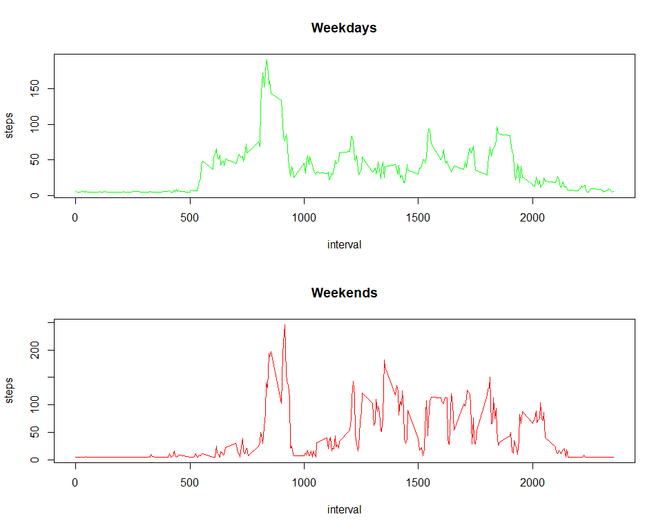

```r
# to get weekday and weekend from the data.
weekday_data <- activity[activity$dayType =="weekday",]
weekend_data <- activity[activity$dayType == "weekend",]

weekday_stepInterval <- aggregate(steps~interval, weekday_data,mean)
weekend_stepInterval <- aggregate(steps~interval, weekend_data,mean)

# plotting
par(mfrow = c(2,1))
plot(weekday_stepInterval, type='l', col='green', main="Weekdays")
plot(weekend_stepInterval,type='l', col="red", main="Weekends")
```